# Acerca de los zombies

# El paso de los zombies por la historia

### *Hablemos de lo que es un zombie…*

*¿Qué es un zombie?*

Se trata de un cadáver humano reanimado que come carne humana.

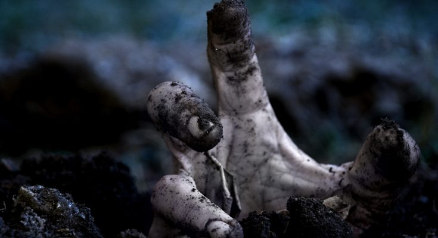

*¿De dónde vienen los zombies?*

Los zombies han estado presentes a lo largo de la historia de la humanidad. Los encontramos en la mitología, la religión, la literatura y el folclore. Tienen origen de las creencias espirituales afrocaribeñas del vudú. Eran personas controladas por poderosos hechiceros. Sin embargo, para sus etimologías tenemos diversos posibles orígenes: La primera es *“jumbie”* que proviene del caribe y significa *“fantasma”*. Otro posible orígen es *“nzambi”* que en el Kongo significa *“Espíritu de una persona muerta”* Y según el diccionario Merriam-Webster, la palabra *“zonbi”* se utilizaba en el criollo de Luisiana o criollo haitiano. En la cultura criolla el *“zonbi”* representa a una persona que falleció y regreso a la vida, pero sin posibilidad de habla ni libre albedrío.

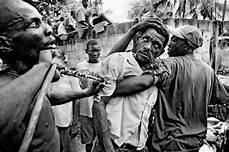

# *¿Cómo surgen en la cultura pop?*

Se hacen populares en el horror moderno. Gracias al éxito de “Night of the Living Dead” estrenada en 1968 y producida por George Romero. Los zombies modernos son diferentes a los zombies representados en el vudú y el folclore. En su mayoria siguen el estandar de los zombies representados en la película *“La noche de los muertos vivientes”*. Son monstruos que no sienten dolor y con gran apetito por carne humana. Matan, comen o infectan personas. Se mueven a pasos lentos e irregulares y se encuentran en proceso de descompocisión. Los zombies modernos son relacionados con el apocalipsis o al colapso de la civilización.

[figure not shown]

# *Consejos para sobrevivir a un apocalipsis zombie*

Cuando un zombie ataca, mordiendo a un individuo, deja abierta una herida. Esta herida tiene saliva del zombie dentro y alrededor. El fluido se mezcla con la sangre, infectando al individuo.

1. Busca refugio Puede ser una montaña, lugares altos o amurallados. Nota: Los zombies no saben escalar.
2. Guarda suministros Almacena agua y comida enlatada. Aprende a potabilizar agua.
3. Ten a la mano tu kit de supervivencia De preferencia una mochila. Tiene que estar equipada para largos viajes de 72 horas.
4. Busca tener una buena condición No sabemos si nos tocarán zombies rápidos o lentos. Haz entrenamientos de fuerza y cardio. Preparate para correr.

[figure not shown]

# *¿Sobrevivirías en una invasión zombie?*

Siendo realistas y aunque eso suene burdo. No estaríamos preparados para una apocalipsis zombie y eso la mismisíma CDC lo sabe. Para poder sobrevivir necesitamos un arma, ya sea para arrancarles o volarles la cabeza a los zombies. Necesitamos suficientes suministros y un lugar seguro. A lo largo del paso de los zombies por la cultura pop, se han realizado un sin fin de películas y series. Que aunque nos cuentan la historia del autor. Han servido como una guía para que profesionistas de areas sociales, realicen estudios conductuales. Esto gracias a las actitudes y personalidades que denota cada personaje ante la crisis.

[figure not shown]

Fuentes:https://loe.org/images/content/091023/Zombie%20Publication.pdf?fbclid=IwAR0qhZWhNFtYSwqFg-aF6_IwrSxL45tljGoUiR7BCq1upJyRflCrl9sfZuo https://situaciondemergencia.es/como-sobrevivir-a-un-apocalipsis-zombie/ Imagenes: https://quieroimagenes.com/wp-content/uploads/mano-zombie-735x400.jpg https://tse1.mm.bing.net/th?id=OIP.ZZr_zw2s914sVPTIqrOFjwHaE6&pid=Api&P=0&w=229&h=152 https://www.themoviedb.org/t/p/w220_and_h330_face/gCZDVukBtz90MskMjEE2dYTSMEl.jpg https://tse2.mm.bing.net/th?id=OIP.4_RK3MzxvVunvnA1Z8voKgHaEK&pid=Api&P=0&w=327&h=185 https://tse2.mm.bing.net/th?id=OIP.4_RK3MzxvVunvnA1Z8voKgHaEK&pid=Api&P=0&w=327&h=185